# Chapter 3

# Libraries

```r
library(ggplot2)
library(magrittr)
library(dplyr)
library(tidyverse)
library(psych)
library(reshape2)
library(GPArotation)
```

# Brand Data

There are 9 variables here. Can the data be described in less number of variables?

## EDA

```r
load("/Users/jasonchan/MSTAT/STAT8019_Marketing_Analytics/lecture notes/chap3r/brand.RData")

head(brand.ratings)
```

|  | perform | leader | latest | fun | serious | bargain | value | trendy | rebuy | brand |
| --- | --- | --- | --- | --- | --- | --- | --- | --- | --- | --- |
| 1 | 2 | 4 | 8 | 8 | 2 | 9 | 7 | 4 | 6 | a |
| 2 | 1 | 1 | 4 | 7 | 1 | 1 | 1 | 2 | 2 | a |
| 3 | 2 | 3 | 5 | 9 | 2 | 9 | 5 | 1 | 6 | a |
| 4 | 1 | 6 | 10 | 8 | 3 | 4 | 5 | 2 | 1 | a |
| 5 | 1 | 1 | 5 | 8 | 1 | 9 | 9 | 1 | 1 | a |
| 6 | 2 | 8 | 9 | 5 | 3 | 8 | 7 | 1 | 2 | a |

```r
describe(brand.ratings, skew = F, ranges = F)
```

|  | vars | n | mean | sd | se |
| --- | --- | --- | --- | --- | --- |
| perform | 1 | 1000 | 4.49 | 3.20 | 0.10 |
| leader | 2 | 1000 | 4.42 | 2.61 | 0.08 |
| latest | 3 | 1000 | 6.20 | 3.08 | 0.10 |
| fun | 4 | 1000 | 6.07 | 2.74 | 0.09 |
| serious | 5 | 1000 | 4.32 | 2.78 | 0.09 |
| bargain | 6 | 1000 | 4.26 | 2.67 | 0.08 |
| value | 7 | 1000 | 4.34 | 2.40 | 0.08 |
| trendy | 8 | 1000 | 5.22 | 2.74 | 0.09 |
| rebuy | 9 | 1000 | 3.73 | 2.54 | 0.08 |
| brand* | 10 | 1000 | 5.50 | 2.87 | 0.09 |

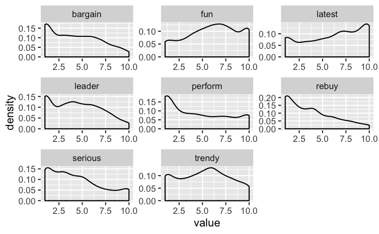

```r
brand.ratings %>%
  keep(is.numeric) %>%                     # Keep only numeric columns
  gather() %>%                             # Convert to key-value pairs
  ggplot(aes(value)) +                     # Plot the values
    facet_wrap(~ key, scales = "free") +   # In separate panels
    geom_density()
```

### Correlation

```r
print(cor(x=brand.ratings[, 1:9]), digits = 2)
```

```
        perform leader latest    fun serious bargain  value  trendy
perform  1.0000  0.500 -0.122 -0.256  0.3592  0.0571  0.102  0.0087
leader   0.5002  1.000  0.027 -0.290  0.5712  0.0331  0.118  0.0665
latest  -0.1224  0.027  1.000  0.245  0.0100 -0.2544 -0.343  0.6276
fun     -0.2563 -0.290  0.245  1.000 -0.2811 -0.0666 -0.145  0.1280
serious  0.3592  0.571  0.010 -0.281  1.0000 -0.0027  0.024  0.1210
bargain  0.0571  0.033 -0.254 -0.067 -0.0027  1.0000  0.740 -0.3505
value    0.1019  0.118 -0.343 -0.145  0.0238  0.7396  1.000 -0.4345
trendy   0.0087  0.067  0.628  0.128  0.1210 -0.3505 -0.435  1.0000
rebuy    0.3067  0.209 -0.397 -0.237  0.1807  0.4674  0.506 -0.2982
        rebuy
perform  0.31
leader   0.21
latest  -0.40
fun     -0.24
serious  0.18
bargain  0.47
value    0.51
trendy  -0.30
rebuy    1.00
```

- Perform, serious, and leader are positively correlated
- Trendy and latest are positively correlated
- Bargain, value, and rebuy are positively correlated

## Factor Analysis using PCA method (THIS IS NOT PCA but PCFA)

- `principal` uses standardized values (using the correlation matrix), hence the variance of each variable is 1
- Since `n=9`, the total variance is 9

```r
fit <- principal(r=brand.ratings[, 1:9], nfactors = 9, rotate = "none")
fit
```

```
Principal Components Analysis
Call: principal(r = brand.ratings[, 1:9], nfactors = 9, rotate = "none")
Standardized loadings (pattern matrix) based upon correlation matrix
```

|  | PC1 | PC2 | PC3 | PC4 | PC5 | PC6 | PC7 | PC8 | PC9 | h2 | u2 | com |
| --- | --- | --- | --- | --- | --- | --- | --- | --- | --- | --- | --- | --- |
| perform | 0.41 | 0.61 | -0.04 | 0.45 | 0.37 | -0.25 | 0.23 | -0.08 | 0.03 | 1 | -1.332268e-15 | 4.322151 |
| leader | 0.36 | 0.76 | 0.10 | 0.08 | -0.24 | -0.22 | -0.38 | 0.16 | -0.09 | 1 | 1.332268e-15 | 2.669652 |
| latest | -0.64 | 0.29 | 0.55 | -0.18 | 0.08 | -0.13 | -0.12 | -0.36 | 0.03 | 1 | 0.000000e+00 | 3.492384 |
| fun | -0.43 | -0.36 | 0.43 | 0.64 | -0.26 | 0.10 | 0.00 | 0.04 | 0.02 | 1 | -2.220446e-16 | 3.832059 |
| serious | 0.28 | 0.74 | 0.04 | -0.08 | -0.44 | 0.29 | 0.28 | -0.10 | 0.04 | 1 | 7.771561e-16 | 2.810582 |
| bargain | 0.69 | -0.32 | 0.51 | -0.14 | -0.01 | -0.10 | 0.18 | 0.03 | -0.32 | 1 | -1.110223e-15 | 3.180505 |
| value | 0.77 | -0.27 | 0.38 | -0.13 | -0.05 | -0.16 | 0.01 | 0.08 | 0.36 | 1 | 0.000000e+00 | 2.495118 |
| trendy | -0.61 | 0.46 | 0.39 | -0.14 | 0.29 | 0.19 | 0.10 | 0.34 | 0.03 | 1 | 0.000000e+00 | 4.440638 |
| rebuy | 0.76 | 0.02 | 0.13 | 0.11 | 0.28 | 0.49 | -0.24 | -0.11 | -0.01 | 1 | 7.771561e-16 | 2.501644 |

```
                       PC1  PC2  PC3  PC4  PC5  PC6  PC7  PC8  PC9
SS loadings           2.98 2.10 1.08 0.73 0.64 0.53 0.39 0.31 0.24
Proportion Var        0.33 0.23 0.12 0.08 0.07 0.06 0.04 0.03 0.03
Cumulative Var        0.33 0.56 0.68 0.76 0.84 0.89 0.94 0.97 1.00
Proportion Explained  0.33 0.23 0.12 0.08 0.07 0.06 0.04 0.03 0.03
Cumulative Proportion 0.33 0.56 0.68 0.76 0.84 0.89 0.94 0.97 1.00

Mean item complexity =  3.3
Test of the hypothesis that 9 components are sufficient.

The root mean square of the residuals (RMSR) is  0
 with the empirical chi square  0  with prob <  NA

Fit based upon off diagonal values = 1
```

- First 4 factors already explain 76% of the variance
- If we use **Latent Root Criteria**, then only choose factors that are > 1, which is this case are the first 3 factors
- If scree plot, elbow at 3, so first 2 factors

### Scree Plot

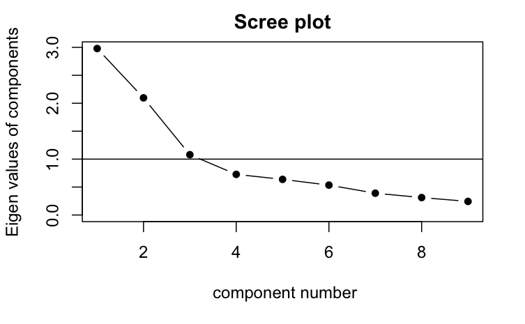

```r
scree(rx=brand.ratings[, 1:9], factors = F)
```

### Decide on 3 Factors

- Based on all the analysis, a 3 factor model is decided to be used

```r
# refit the 3 factor model

fit <- principal(r=brand.ratings[, 1:9], nfactors = 3, rotate = "none")
```

```r
fit$loadings
```

```
Loadings:
        PC1    PC2    PC3
perform  0.410  0.608
leader   0.355  0.758
latest  -0.639  0.292  0.553
fun     -0.433 -0.363  0.434
serious  0.276  0.739
bargain  0.689 -0.316  0.509
value    0.772 -0.275  0.384
trendy  -0.606  0.461  0.385
rebuy    0.758         0.129

                 PC1   PC2   PC3
SS loadings    2.979 2.097 1.079
Proportion Var 0.331 0.233 0.120
Cumulative Var 0.331 0.564 0.684
```

- This implies the following:
  - $Z_{perform} = 0.41F_{1} + 0.61F_{2} - 0.04F_{3} + \epsilon_1$
  - $Z_{leader} = 0.36F_{1} + 0.76F_{2} + 0.10F_{3} + \epsilon_2$
  - …

```r
fit$communality
```

```
  perform    leader    latest       fun   serious   bargain
0.5392849 0.7112471 0.8000848 0.5076248 0.6241318 0.8338305
    value    trendy     rebuy
0.8191862 0.7282532 0.5914588
```

```r
fit$uniquenesses
```

```
  perform    leader    latest       fun   serious   bargain
0.4607151 0.2887529 0.1999152 0.4923752 0.3758682 0.1661695
    value    trendy     rebuy
0.1808138 0.2717468 0.4085412
```

- `h2` is the communality and `u2` is the uniqueness, sum is 1
  - 54% of variance of `perform` explained by 3 factors, $(0.41)^2+(0.61)^2+(-0.04)^2 = 0.54$
  - …

### Apply Rotation with `rotate=varimax`

- Rotation doesn’t change the communalities and uniqueness
- Total variance explain will also still be the same
- Loadings will be different

```r
#rotate="varimax" varimax rotation
#method="regression" factor scores estimated by regression method
fitr <- principal(r=brand.ratings[,1:9],nfactors=3,rotate="varimax",method="regression")
fitr
```

```
Principal Components Analysis
Call: principal(r = brand.ratings[, 1:9], nfactors = 3, rotate = "varimax",
    method = "regression")
Standardized loadings (pattern matrix) based upon correlation matrix
```

|  | RC2 | RC1 | RC3 | h2 | u2 | com |
| --- | --- | --- | --- | --- | --- | --- |
| perform | 0.72 | 0.10 | -0.09 | 0.5392849 | 0.4607151 | 1.063883 |
| leader | 0.83 | 0.10 | 0.09 | 0.7112471 | 0.2887529 | 1.054548 |
| latest | -0.02 | -0.20 | 0.87 | 0.8000848 | 0.1999152 | 1.107135 |
| fun | -0.53 | 0.06 | 0.48 | 0.5076248 | 0.4923752 | 2.012360 |
| serious | 0.78 | 0.01 | 0.09 | 0.6241318 | 0.3758682 | 1.026574 |
| bargain | -0.03 | 0.91 | -0.08 | 0.8338305 | 0.1661695 | 1.017652 |
| value | 0.04 | 0.88 | -0.21 | 0.8191862 | 0.1808138 | 1.120434 |
| trendy | 0.16 | -0.33 | 0.77 | 0.7282532 | 0.2717468 | 1.454997 |
| rebuy | 0.32 | 0.62 | -0.32 | 0.5914588 | 0.4085412 | 2.039589 |

```
                       RC2  RC1  RC3
SS loadings           2.24 2.16 1.76
Proportion Var        0.25 0.24 0.20
Cumulative Var        0.25 0.49 0.68
Proportion Explained  0.36 0.35 0.29
Cumulative Proportion 0.36 0.71 1.00

Mean item complexity =  1.3
Test of the hypothesis that 3 components are sufficient.

The root mean square of the residuals (RMSR) is  0.08
 with the empirical chi square  509.66  with prob <  1.9e-101

Fit based upon off diagonal values = 0.93
```

In terms of the rotated loadings:

- $Z_{perform} = 0.72F^*_1 + 0.10F^*_2 - 0.09F^*_3 + \epsilon_1$
- …

#### Rotation Matrix

- This is the rotation matrix **T** that is in $LT=L^*$

```r
fitr$rot.mat[c(1,2,3), c(2,1,3)]
```

```
           [,1]       [,2]       [,3]
[1,]  0.4046359  0.7239827 -0.5586759
[2,]  0.9134025 -0.2903499  0.2852944
[3,] -0.0443367  0.6257363  0.7787736
```

### Weights and Scores

```r
fitr$weights
```

```
                RC2          RC1         RC3
perform  0.32220484 -0.007812555 -0.02301553
leader   0.37462977  0.038590336  0.10790099
latest   0.01751890  0.125126337  0.55892722
fun     -0.23463257  0.196561000  0.34513466
serious  0.35773089 -0.010863999  0.07936525
bargain -0.06516430  0.506320402  0.19499200
value   -0.03059865  0.448147777  0.09457163
trendy   0.10279176  0.012303175  0.45441432
rebuy    0.10712385  0.256173984 -0.04570612
```

```r
head(scale(brand.ratings[, 1:9]))
```

```
        perform     leader     latest        fun    serious
[1,] -0.7766617 -0.1598662  0.5864084  0.7040175 -0.8361532
[2,] -1.0888247 -1.3099826 -0.7131117  0.3396192 -1.1960986
[3,] -0.7766617 -0.5432383 -0.3882316  1.0684159 -0.8361532
[4,] -1.0888247  0.6068781  1.2361685  0.7040175 -0.4762078
[5,] -1.0888247 -1.3099826 -0.3882316  0.7040175 -1.1960986
[6,] -0.7766617  1.3736224  0.9112885 -0.3891774 -0.4762078
         bargain      value     trendy      rebuy
[1,]  1.77763492  1.1102404 -0.4449143  0.8932671
[2,] -1.22195997 -1.3912400 -1.1742820 -0.6786944
[3,]  1.77763492  0.2764136 -1.5389658  0.8932671
[4,] -0.09711188  0.2764136 -1.1742820 -1.0716848
[5,]  1.77763492  1.9440672 -1.5389658 -1.0716848
[6,]  1.40268556  1.1102404 -1.5389658 -0.6786944
```

- $Z_{perform}$ is the standardized value of Z
- Observation 1
  - Factor 1 score $f^*_1 = 0.32Z_{perform} + ... +0.11Z_{rebuy}$
  - $f^*_1 = 0.32(-0.78) + ... +0.11(0.89) = -0.86$

```r
head(fitr$scores)
```

```
            RC2        RC1        RC3
[1,] -0.8640183  1.8417025  0.7136232
[2,] -1.4328558 -1.4820205 -1.3650147
[3,] -1.1971608  1.3894434 -0.3227385
[4,] -0.6749925  0.1158785  0.5092342
[5,] -1.8897715  1.5385629 -0.3050969
[6,] -0.1549943  1.1167409  0.2135236
```

### Mean Scores by Brand

```r
scores<-cbind(brand.ratings["brand"],fitr$scores)

#group means of factor scores
tb<-aggregate(.~brand,data=scores,FUN=mean)
tb
```

| brand | RC2 | RC1 | RC3 |
| --- | --- | --- | --- |
| a | -1.09626675 | 0.20901475 | 0.1946609 |
| b | 1.45928881 | 0.07966015 | 0.6063110 |
| c | 1.32029981 | -0.69078498 | -0.2835684 |
| d | -0.61772538 | -0.91066342 | 0.2555178 |
| e | -0.18654770 | 0.60439712 | 0.6027842 |
| f | 0.29538558 | 1.04216033 | -0.8678992 |
| g | 0.05864475 | 1.07961147 | -1.3266879 |
| h | -0.22979231 | -0.67510683 | 0.6866718 |
| i | -0.07598665 | -0.42151091 | 0.4392064 |
| j | -0.92730016 | -0.31677767 | -0.3069966 |

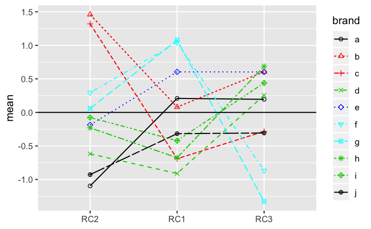

```r
#plot of the group means
tbm<-melt(tb,id.vars='brand')

ggplot(tbm,
       aes(x = variable, y = value, group = brand, colour = brand)) +
  geom_line(aes(linetype=brand))+
  geom_point(aes(shape=brand)) +
  geom_hline(yintercept=0) +
  labs(x=NULL,y="mean") +
  scale_shape_manual(values=1:nlevels(tbm$brand)) +
  scale_color_manual(values=c(1,2,2,3,4,5,5,3,3,1))
```

**Interpretation**

- Brand F, G, high at Value (factor 2)
- Brands B, C high at Leader (factor 1)
- Brands E: high at Latest (factor 3) and high at Value (factor 2)
- Brands A, J: low at Leader (factor 1) ⇒ high at Fun
- Brands D, H, I: high at Latest (factor 3) and low at Value (factor 2)

### 2-Factor Solution

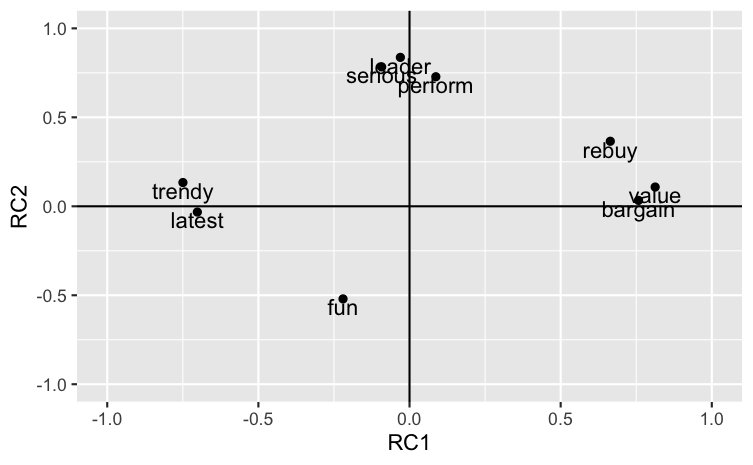

```r
#2-factor solution
fit <- principal(r=brand.ratings[1:9], nfactors=2,rotate="varimax")

#plot of factor loadings
ld<-data.frame(fit$loadings[,1:2])
ggplot(data=ld,aes(x=RC1,y=RC2))+
  geom_point()+
  geom_text(aes(label=rownames(ld),vjust=1))+
  geom_vline(aes(xintercept=0))+
  geom_hline(aes(yintercept=0))+
  coord_cartesian(xlim = c(-1,1),ylim=c(-1,1))
```

- Consistent with results from the 3 factor solution, similar grouping
- Even with 2 dimensions, structure still retain
- Leader, serious, perform are correlated
- Value, rebuy and bargain are correlated
- Latest, trendy are correlated
- Fun on its own

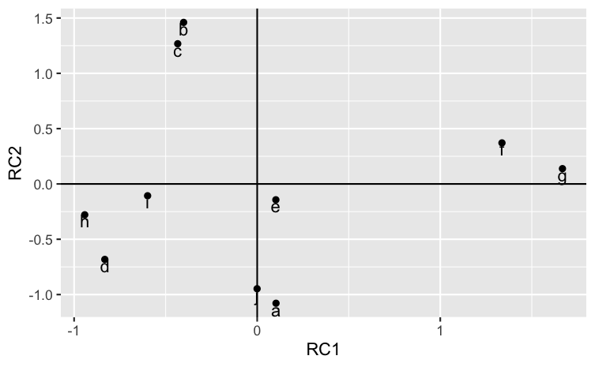

```r
#means factor scores
sc<-data.frame(fit$scores,brand=brand.ratings$brand)
tb<-aggregate(.~brand,data=sc,FUN=mean)
#plot
ggplot(data=tb,aes(x=RC1,y=RC2))+
  geom_point()+
  geom_text(aes(label=brand,vjust=1))+
  geom_vline(aes(xintercept=0))+
  geom_hline(aes(yintercept=0))
```

- Comparing the factor loadings plot and the factor scores plot
  - B, C
- Leader, serious, perform
  - F, G
- Value, rebuy, bargain
  - A, J
- Fun
  - D, H, I
- Latest, trendy
  - E
- No strong characteristic

#### Clustering using Ward’s Method

Based on plot above, it seems like there are 5 groups. Clustering can be done to see if it is consistent with above groupings.

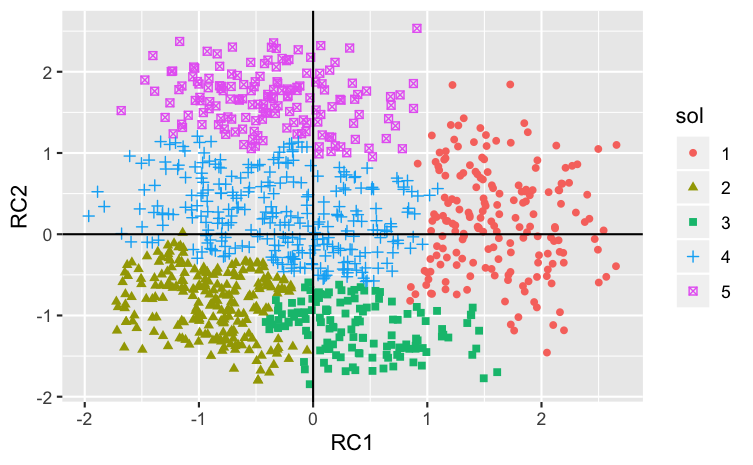

```r
dist<-dist(sc[1:2],method="euclidean")^2
fitc <- hclust(dist, method="ward.D")
sol <- cutree(fitc, k=5)
sol<-data.frame(sol,sc)
sol$sol<-factor(sol$sol)
ggplot(data=sol,aes(x=RC1,y=RC2,colour=sol))+
  geom_point(aes(shape=sol)) +
  geom_vline(aes(xintercept=0))+
  geom_hline(aes(yintercept=0))
```

```r
table(sol[c("sol", "brand")])
```

```
   brand
sol  a  b  c  d  e  f  g  h  i  j
  1  4  0  0  1  7 76 89  0  3  2
  2 34  1  1 70 11  0  0 51 34 32
  3 50  0  0  9 19  0  2  2  6 50
  4 12 24 36 20 58 19  6 47 52 15
  5  0 75 63  0  5  5  3  0  5  1
```

# Preference Data

Instead of Principle Component method, the **Maximum Likelihood** method will be used for obtaining the Factors.

## EDA

```r
pref<-read.csv("/Users/jasonchan/MSTAT/STAT8019_Marketing_Analytics/lecture notes/chap3r/pref.csv", header = TRUE)

colnames(pref) <- c("id", "taste", "goodbuy", "flavor", "suitable", "energy")

head(pref)
```

|  | id | taste | goodbuy | flavor | suitable | energy |
| --- | --- | --- | --- | --- | --- | --- |
| 1 | 1 | 3 | 3 | 3 | 3 | 2 |
| 2 | 2 | 4 | 4 | 4 | 3 | 2 |
| 3 | 3 | 4 | 5 | 4 | 5 | 3 |
| 4 | 4 | 6 | 4 | 6 | 4 | 2 |
| 5 | 5 | 4 | 5 | 4 | 4 | 3 |
| 6 | 6 | 5 | 4 | 5 | 4 | 2 |

```r
describe(pref, skew = F, ranges = F)
```

|  | vars | n | mean | sd | se |
| --- | --- | --- | --- | --- | --- |
| id | 1 | 50 | 25.50 | 14.58 | 2.06 |
| taste | 2 | 50 | 4.42 | 1.03 | 0.15 |
| goodbuy | 3 | 50 | 4.36 | 1.01 | 0.14 |
| flavor | 4 | 50 | 4.14 | 0.97 | 0.14 |
| suitable | 5 | 50 | 4.70 | 1.37 | 0.19 |
| energy | 6 | 50 | 2.90 | 0.89 | 0.13 |

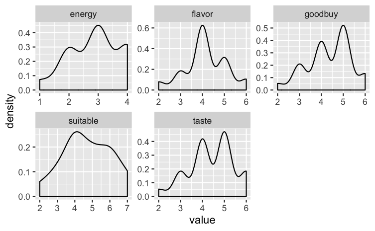

```r
pref[, 2:6] %>%
  keep(is.numeric) %>%                     # Keep only numeric columns
  gather() %>%                             # Convert to key-value pairs
  ggplot(aes(value)) +                     # Plot the values
    facet_wrap(~ key, scales = "free") +   # In separate panels
    geom_density()
```

```r
as.data.frame(round(cor(pref[, 2:6]), 2))
```

|  | taste | goodbuy | flavor | suitable | energy |
| --- | --- | --- | --- | --- | --- |
| taste | 1.00 | 0.40 | 0.90 | 0.62 | 0.20 |
| goodbuy | 0.40 | 1.00 | 0.45 | 0.73 | 0.73 |
| flavor | 0.90 | 0.45 | 1.00 | 0.58 | 0.21 |
| suitable | 0.62 | 0.73 | 0.58 | 1.00 | 0.71 |
| energy | 0.20 | 0.73 | 0.21 | 0.71 | 1.00 |

- Taste and Flavor (correlation = 0.899), Good buy for money and Provides lots of energy (correlation = 0.728) form groups
- Suitable for snack closer to (Good buy for money and Provides lots of energy) (correlation = 0.730 and 0.712) than (Taste and Flavor) (correlation = 0.623 and 0.584)
- Linear relationships between the variables can be explained in terms of 2 (or 3) common factors

### Scree Plot

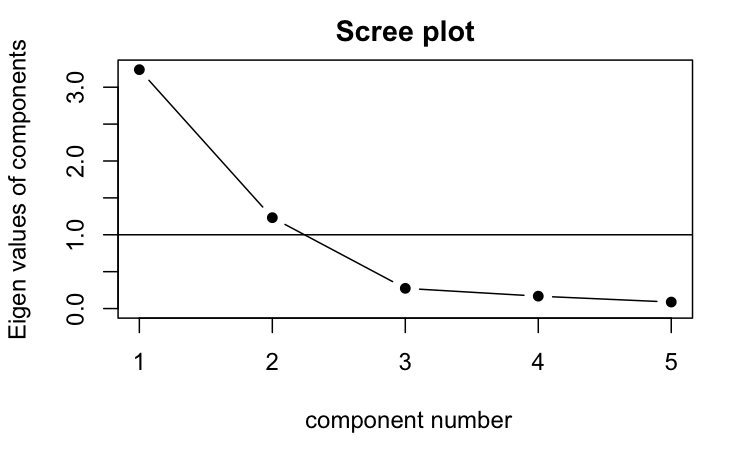

```r
#scree plot
scp<-scree(pref[2:6],factors = F)
```

These are the eigen values estimated by the principle component method, unrotated.

```r
scp$pc
```

```
[1] 3.23798738 1.23163132 0.27413866 0.16811889 0.08812375
```

## Factor Analysis using MLE

Unrotated

```r
fit <- fa(r=pref[, 2:6], nfactors = 2, rotate = "none", fm = "ml")
fit
```

```
Factor Analysis using method =  ml
Call: fa(r = pref[, 2:6], nfactors = 2, rotate = "none", fm = "ml")
Standardized loadings (pattern matrix) based upon correlation matrix
```

|  | ML1 | ML2 | h2 | u2 | com |
| --- | --- | --- | --- | --- | --- |
| taste | 0.97 | -0.14 | 0.9699071 | 0.03009287 | 1.041780 |
| goodbuy | 0.51 | 0.65 | 0.6918481 | 0.30815189 | 1.896147 |
| flavor | 0.91 | -0.10 | 0.8346757 | 0.16532426 | 1.022903 |
| suitable | 0.72 | 0.55 | 0.8215108 | 0.17848922 | 1.880424 |
| energy | 0.33 | 0.86 | 0.8412117 | 0.15878830 | 1.291588 |

```
                       ML1  ML2
SS loadings           2.66 1.50
Proportion Var        0.53 0.30
Cumulative Var        0.53 0.83
Proportion Explained  0.64 0.36
Cumulative Proportion 0.64 1.00

Mean item complexity =  1.4
Test of the hypothesis that 2 factors are sufficient.

The degrees of freedom for the null model are  10  and the objective function was  4.12 with Chi Square of  191.72
The degrees of freedom for the model are 1  and the objective function was  0.06

The root mean square of the residuals (RMSR) is  0.02
The df corrected root mean square of the residuals is  0.05

The harmonic number of observations is  50 with the empirical chi square  0.25  with prob <  0.62
The total number of observations was  50  with Likelihood Chi Square =  2.75  with prob <  0.098

Tucker Lewis Index of factoring reliability =  0.901
RMSEA index =  0.186  and the 90 % confidence intervals are  0 0.472
BIC =  -1.17
Fit based upon off diagonal values = 1
Measures of factor score adequacy
                                                   ML1  ML2
Correlation of (regression) scores with factors   0.99 0.95
Multiple R square of scores with factors          0.98 0.89
Minimum correlation of possible factor scores     0.95 0.79
```

```r
fit$communalities
```

```
    taste   goodbuy    flavor  suitable    energy
0.9699071 0.6918458 0.8346754 0.8215120 0.8412116
```

- Based on the Chi-Squared test above, 2 factors are sufficient, 83% of variance can be explained
- R always shows the Barlett Corrected $\chi^2$ statistic

### Factor Loadings

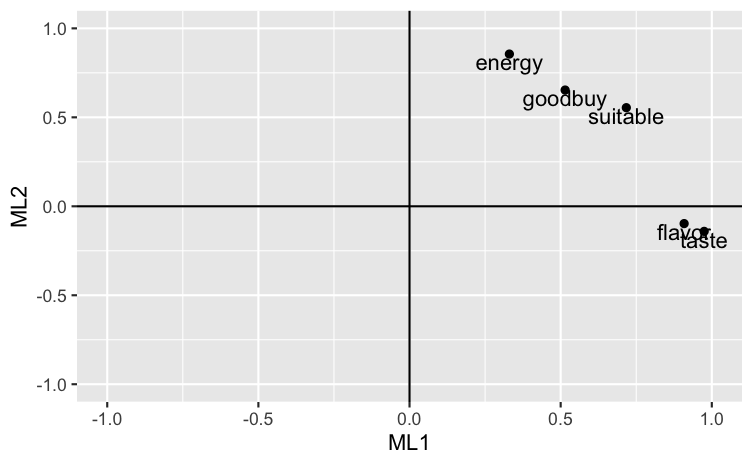

```r
#factor loadings
ld<-data.frame(fit$loadings[,1:fit$factors])
ggplot(data=ld,aes(x=ML1,y=ML2))+
  geom_point()+
  geom_text(aes(label=rownames(ld),vjust=1))+
  geom_vline(aes(xintercept=0))+
  geom_hline(aes(yintercept=0))+
  coord_cartesian(xlim = c(-1,1),ylim=c(-1,1))
```

### With Rotation

```r
#varimax rotation
#scores="regression" regression method for factor scores
fitr<-fa(r=pref[2:6],nfactors=2,rotate="varimax",fm="ml",scores="regression")
print(fitr, digits = 3)
```

```
Factor Analysis using method =  ml
Call: fa(r = pref[2:6], nfactors = 2, rotate = "varimax", scores = "regression",
    fm = "ml")
Standardized loadings (pattern matrix) based upon correlation matrix
```

|  | ML2 | ML1 | h2 | u2 | com |
| --- | --- | --- | --- | --- | --- |
| taste | 0.186 | 0.967 | 0.9699071 | 0.03009287 | 1.074163 |
| goodbuy | 0.786 | 0.272 | 0.6918481 | 0.30815189 | 1.236412 |
| flavor | 0.206 | 0.890 | 0.8346757 | 0.16532426 | 1.106715 |
| suitable | 0.759 | 0.496 | 0.8215108 | 0.17848922 | 1.722575 |
| energy | 0.917 | 0.032 | 0.8412117 | 0.15878830 | 1.002380 |

```
                        ML2   ML1
SS loadings           2.111 2.048
Proportion Var        0.422 0.410
Cumulative Var        0.422 0.832
Proportion Explained  0.507 0.493
Cumulative Proportion 0.507 1.000

Mean item complexity =  1.2
Test of the hypothesis that 2 factors are sufficient.

The degrees of freedom for the null model are  10  and the objective function was  4.123 with Chi Square of  191.716
The degrees of freedom for the model are 1  and the objective function was  0.061

The root mean square of the residuals (RMSR) is  0.016
The df corrected root mean square of the residuals is  0.05

The harmonic number of observations is  50 with the empirical chi square  0.246  with prob <  0.62
The total number of observations was  50  with Likelihood Chi Square =  2.746  with prob <  0.0975

Tucker Lewis Index of factoring reliability =  0.9009
RMSEA index =  0.1858  and the 90 % confidence intervals are  0 0.4717
BIC =  -1.166
Fit based upon off diagonal values = 0.999
Measures of factor score adequacy
                                                    ML2   ML1
Correlation of (regression) scores with factors   0.950 0.984
Multiple R square of scores with factors          0.903 0.967
Minimum correlation of possible factor scores     0.806 0.935
```

- Factor 1
  - Good buy for money (X2), Suitable for snack (X4) and Provides lots of energy (X5) define factor 1 (high loadings on factor 1, small or negligible loadings on factor 2)
  - Nutritional factor
- Factor 2
  - Taste (X1) and Flavor (X3) define factor 2 (high loadings on factor 2, small or negligible loadings on factor 1)
  - Taste factor

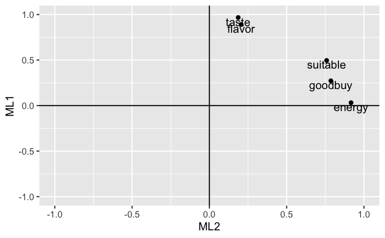

```r
#loading plot
ld<-data.frame(fitr$loadings[,1:fitr$factors])
ggplot(data=ld,aes(x=ML2,y=ML1))+
  geom_point()+
  geom_text(aes(label=rownames(ld),vjust=1))+
  geom_vline(aes(xintercept=0))+
  geom_hline(aes(yintercept=0))+
  coord_cartesian(xlim = c(-1,1),ylim=c(-1,1))
```

```r
fitr$weights
```

```
                 ML2         ML1
taste    -0.21610865  0.89143367
goodbuy   0.22537278 -0.03608151
flavor   -0.01599958  0.14405822
suitable  0.34233328 -0.01748175
energy    0.55587471 -0.14041265
```

```r
head(fitr$scores)
```

```
            ML2        ML1
[1,] -0.9766664 -1.1831089
[2,] -0.9784095 -0.2065078
[3,]  0.3712058 -0.4262535
[4,] -1.1811096  1.8057539
[5,]  0.1220469 -0.4135299
[6,] -0.9551801  0.7932612
```

- As usual, communalities and total variance explained doesn’t change.

### Perceptual Plot

- Individual plots of each observation with Factor Scores

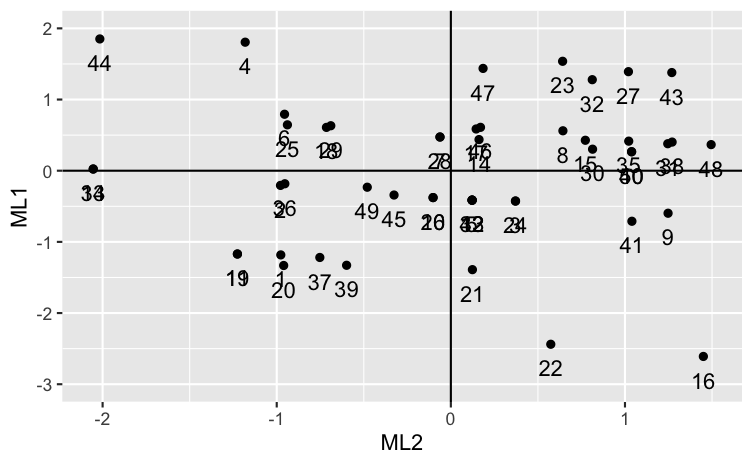

```r
#factor scores
sc<-data.frame(fitr$scores)
ggplot(data=sc,aes(x=ML2,y=ML1))+
  geom_point()+
  geom_vline(aes(xintercept=0))+
  geom_hline(aes(yintercept=0))+
  geom_text(aes(label=pref$id,vjust=2))+
  coord_cartesian(ylim=c(-3,2))
```

** ML2 = nutrition , ML1 = taste **